# The demo file for SRBR_SMTSAworkshop

Gang Wu, Tanya Leise, and John Hogenesch

2016-05-16

## 1. The introduction about MetaCycle

### 1.1. General description about MetaCycle

The **MetaCycle** package is mainly used for detecting rhythmic signals from large scale time-series data. It incorporates [ARSER(ARS)](https://github.com/cauyrd/ARSER), [JTK_CYCLE(JTK)](http://openwetware.org/wiki/HughesLab:JTK_Cycle), and [Lomb-Scargle(LS)](http://research.stowers-institute.org/efg/2005/LombScargle/) properly for periodic signal detection, and could also output integrated analysis results if required.

### 1.2. Types of time-series data

The usual time-series data is evenly sampled once at each time point, and the interval between neighbour time points is integer. Not all data are as simple as this. There are datasets with replicate samples, or with missing values, or un-evenly sampled, or sampled with a non-integer interval. Examples of these types of data are shown in the below table.

| Data Type | Point 1 | Point 2 | Point 3 | Point 4 | Point 5 | Point 6 |
| --- | --- | --- | --- | --- | --- | --- |
| The usual data | CT0 | CT4 | CT8 | CT12 | CT16 | CT20 |
| With missing value | CT0 | NA | CT8 | CT12 | CT16 | CT20 |
| With replicates | CT0 | CT0 | CT8 | CT8 | CT16 | CT16 |
| With un-even interval | CT0 | CT2 | CT8 | CT10 | CT16 | CT20 |
| With non-integer interval | CT0 | CT4.5 | CT9 | CT13.5 | CT18 | CT22.5 |

Of course, some datasets may seem combination of two or more of above types of data.

| Data Type | Point 1 | Point 2 | Point 3 | Point 4 | Point 5 | Point 6 |
| --- | --- | --- | --- | --- | --- | --- |
| With replicates and missing value | CT0 | CT0 | CT8 | NA | CT16 | CT16 |
| With un-even interval and replicates | CT0 | CT2 | CT2 | CT10 | CT16 | CT20 |

### 1.3. Method selection

The **meta2d** function in **MetaCycle** is designed to analyze differnt types of time-series datasets, and it could automatically select proper method to analyze different types of input datasets. The implementation strategy used for **meta2d** is shown in the flow chart.

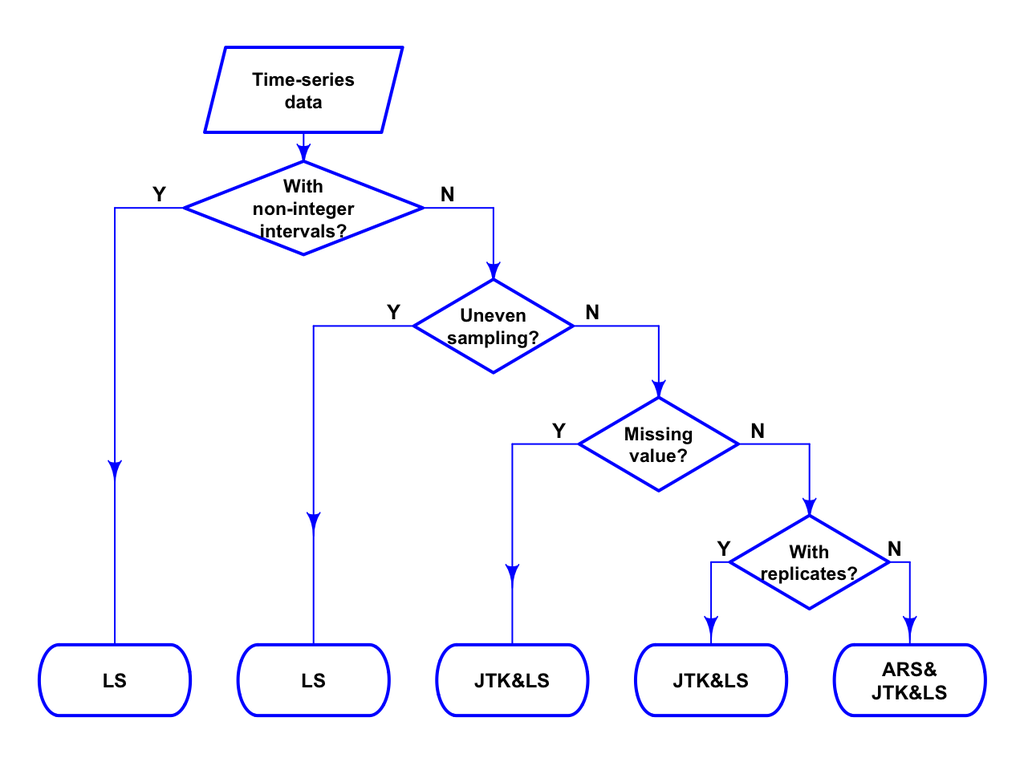

### 1.4. Integration strategies

In addition to selecting proper methods to analyze different kinds of datasets, **meta2d** could also output integrated results from multiple methods. Detail explaination about integration stragegies is in the [vignettes](https://cran.r-project.org/web/packages/MetaCycle/vignettes/implementation.html) of MetaCycle.

##### Pvalue

- - [Fisher’s method](https://en.wikipedia.org/wiki/Fisher%27s_method) is implemented in **meta2d** for integrating multiple p-values.

##### Period and phase

- - The integrated period is an arithmetic mean value of multiple periods, while phase integration based on [mean of circular quantities](https://en.wikipedia.org/wiki/Mean_of_circular_quantities) is implemented in **meta2d**.

##### Amplitude calculation

- - **meta2d** recalculates the amplitude with following model:
    $$Y_i = B + TRE*(t_i - \frac{\sum_{i=1}^n t_i}{n}) + A*cos(2*\pi*\frac{t_i - PHA}{PER})$$
  - B is baseline level of the time-series profile; TRE is trend level of the time-series profile; A is the amplitude of the waveform. PHA and PER are integrated period and phase mentioned above.
  - The baseline and trend level are explained in the below example.

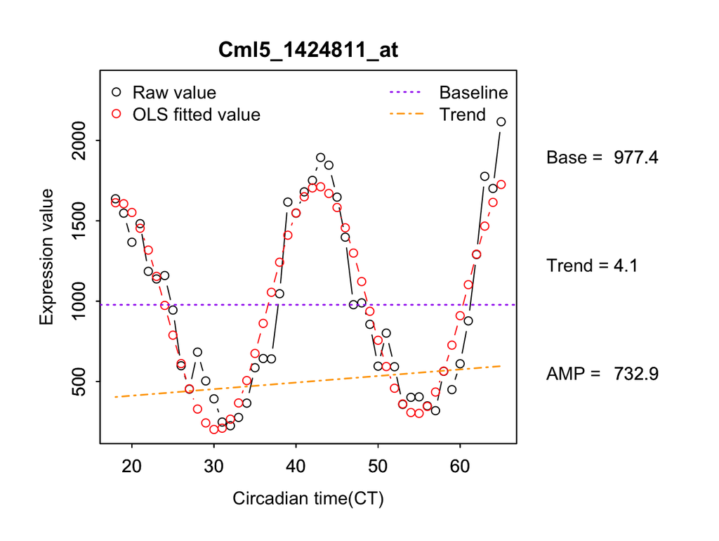

##### About rAMP

- - **meta2d** outputs a relative amplitude value (rAMP), which normalizes amplitude values with expression levels. For example, *Ugt2b34* has a larger amplitude than *Arntl*, but its rAMP is smaller than *Arntl*.

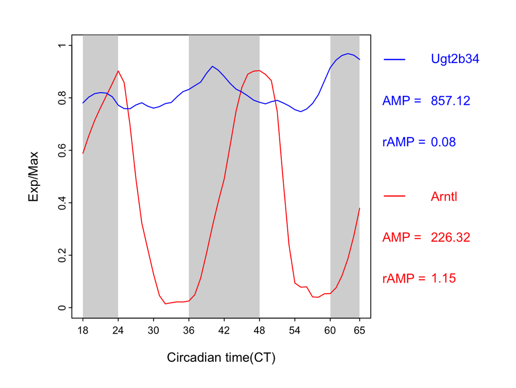

### 1.5. Description about output values

| Column name | Description | Column name | Description |
| --- | --- | --- | --- |
| ARS_pvalue | pvalue from ARS | LS_BH.Q | FDR from LS |
| ARS_BH.Q | FDR from ARS | LS_period | period from LS |
| ARS_period | period from ARS | LS_adjphase | adjusted phase from LS |
| ARS_adjphase | adjusted phase from ARS | LS_amplitude | amplitude from LS |
| ARS_amplitude | amplitude from ARS | meta2d_pvalue | integrated pvalue |
| JTK_pvalue | pvalue from JTK | meta2d_BH.Q | FDR based on integrated pvalue |
| JTK_BH.Q | FDR from JTK | meta2d_period | averaged period |
| JTK_period | period from JTK | meta2d_phase | integrated phase |
| JTK_adjphase | adjusted phase from JTK | meta2d_Base | baseline value given by meta2d |
| JTK_amplitude | amplitude from JTK | meta2d_AMP | amplitude given by meta2d |
| LS_pvalue | pvalue from LS | meta2d_rAMP | relative amplitude |

## 2. Take a quick check about installed software and packages

#### Before the demo, please make sure that you have read the [README](https://github.com/gangwug/SRBR_SMTSAworkshop) file for this workshop.

#### Check the installed RStudio and packages

##### Click the RStudio icon to open it. The RStudio window will show as below (If the Console part(left bottom) does not shows ‘R version 3.3.0’, plese follow [README](https://github.com/gangwug/SRBR_SMTSAworkshop) file for installing the latest R version or switch to the latest R version):

[figure not shown]

##### Type below command in the Console part to check installed packages

```r
# load 'shiny' package
library("shiny")
# load 'MetaCycle' package
library("MetaCycle")
# load 'dplyr' package
library("dplyr")
# load 'ggplot2' package
library("ggplot2")
# load 'cowplot' package
library("cowplot")
```

#### Check downloaded repositories

##### Type below command to check whether “MetaCycleApp-master”, “PSEA-master” and “SRBR_SMTSAworkshop-master” directories are on the desktop of laptop

```r
# change working directory to the desktop
setwd("~/Desktop")
# check required directories under the desktop
dir()
```

#### If all required packages are successfully installed and three requied directories has been downloaded to the desktop of labtop, it would show below records in the Console part:

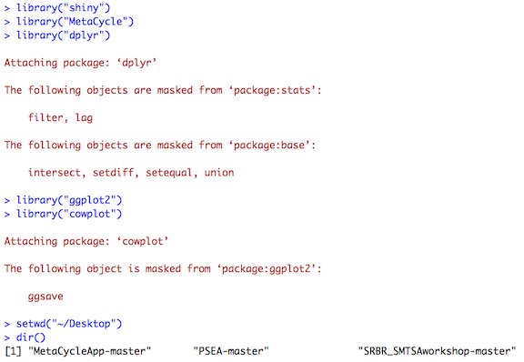

#### Try to open a ‘jar’ file

##### Go to “PSEA-master” directory, and could see two ‘jar’ files-‘MouseHumanConverter.jar’ and ‘PSEA1.1_VectorGraphics.jar’

##### Right click one file and click ‘open’. On mac computer, it may show below dialog, and just click ‘Open’.

[figure not shown]

##### If these two ‘jar’ files could be successfully opened, you could see below two dialogs (If not, please follow [README](https://github.com/gangwug/SRBR_SMTSAworkshop) file to install latest Java).

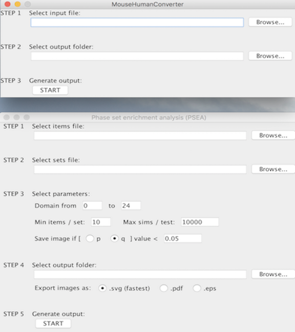

##### Now you could close these two ‘jar’ files, and begin to try **MetaCycle**.

## 3. The demo pipeline about MetaCycle

### 3.1. Open the web application of **meta2d**

##### Option 1: use ‘runGitHub’ function by typing below command in the ‘Console’ window of RStudio (this option requires that the laptop is connected with internet)

```r
# load shiny package
library("shiny")
# use 'runGitHub' function of shiny package
runGitHub("MetaCycleApp", "gangwug")
```

##### Option 2: use ‘runApp’ function by typing below command in the ‘Console’ window of RStudio (this option does not require that the laptop is connected with internet)

```r
# load shiny package
library("shiny")
# use 'runApp' function of shiny package
runApp("~/Desktop/MetaCycleApp-master")
```

##### If the web application is successfully opened, it will show a window like below:

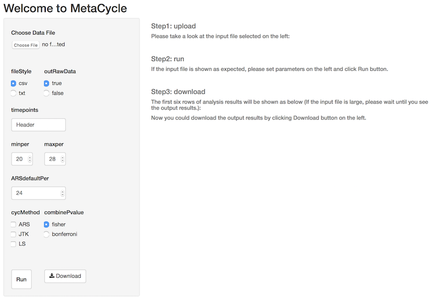